# R Notebook

```
The 'mosaic' package masks several functions from core packages in order to add
additional features.  The original behavior of these functions should not be affected by this.


here() starts at C:/Users/colin/Documents/CodeClan/codeclan_homework_ColinS/week_10/weekend_hw
```

```
[1] "C:/Users/colin/Documents/CodeClan/codeclan_homework_ColinS/week_10/weekend_hw"
```

```r
avocados <- read_csv(here("1_weekend_homework_part1/data/avocado.csv")) %>%
  janitor::clean_names()
```

```
* `` -> ...1
```

Check for NAs in the data set;

```r
avocados %>%
  summarise(across(.cols = everything(), ~ sum(is.na(.))))
```

| x1 | date | average_price | total_volume | x4046 | x4225 | x4770 | total_bags | small_bags | large_bags | x_large_bags | type | year | region |
| --- | --- | --- | --- | --- | --- | --- | --- | --- | --- | --- | --- | --- | --- |
| 0 | 0 | 0 | 0 | 0 | 0 | 0 | 0 | 0 | 0 | 0 | 0 | 0 | 0 |

So there are no NAs to consider.

## Make a test set

The data consists of > 18k observations, so there should be plenty of capacity to create a test set. 10% of 18k is around 1800 observations, which sounds like a reasonable size for a test set.

Make a test index using 10% of the data;

```r
avocado_row_count <- nrow(avocados)

test_index <- sample(1:avocado_row_count, size = avocado_row_count * 0.1)
```

Then create the test and train data sets using this index;

```r
avo_test <- slice(avocados, test_index)
avo_train <- slice(avocados, -test_index)
```

## Process the Data

#### Seasonality

The discussion relates to the growth and harvest of a fruit, so there’s a good chance that there’s a seasonal element to the price that could be a significant factor;

```r
avo_train <- avo_train %>%
  mutate(month = month(as.POSIXlt(date), label = TRUE, abbr = TRUE))
```

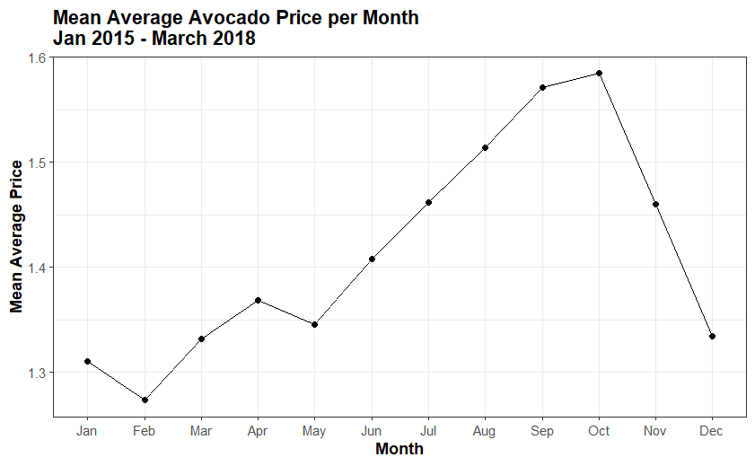

```r
avo_train %>%
  select(month, average_price) %>%
  group_by(month) %>%
  summarise(mean_price_per_month = mean(average_price)) %>%
  ggplot() +
  aes(x = month, y = mean_price_per_month) +
  geom_line(group = 1) +
  geom_point() +
  labs(title = "Mean Average Avocado Price per Month\nJan 2015 - March 2018",
       x = "Month",
       y = "Mean Average Price") +
  theme_bw() +
  theme(title = element_text(face = "bold"))
```

This plot suggests that there is indeed some seasonality. It would be worth retaining the `month` column to check in the model later, but there’s no need to keep the level of detail contained in the `date` column. Variation by day is too much detail.

#### Regions

Considering `region`, there are several values that are very ambiguous such as `plains`, `WestTexNewMexico`, `SouthEast`. Although regional variations may be a significant factor worthy of inclusion in a model, it would be difficult to rationally separate all of the areas into discrete constituent states, so region will also be removed.

```r
avo_train <- avo_train %>%
  select(-c(date, region))
```

#### Other Considerations

The `x1` column appears to be an identifier of individual observations and will not influence the model, so can be removed safely.

```r
avo_train <- avo_train %>%
  select(-x1)
```

It looks likely that there will be aliases in bag sizes;

```r
alias(lm(average_price ~ ., data = avo_train))
```

```
Model :
average_price ~ total_volume + x4046 + x4225 + x4770 + total_bags +
    small_bags + large_bags + x_large_bags + type + year + month
```

The alias function shows nothing at this point, but it looks like `total_bags` = `small_bags` + `large_bags` + `x_large_bags` - verify this a different way, bearing in mind that R is not a perfect calculator when trying to compare floating point numbers;

```r
avo_train %>%
  mutate(bag_check =
           as.integer(total_bags - (small_bags + large_bags + x_large_bags))) %>%
  distinct(bag_check)
```

| bag_check |
| --- |
| 0 |
| -1 |
| 1 |

So it looks like the supposition:

`total_bags` = `small_bags` + `large_bags` + `x_large_bags`

is true - R’s lack of precision in performing floating point calculations leads to rounding errors within +/- 1, which is what is shown in the results.

In conclusion, we can safely remove `total_bags` from the data set, because this can be calculated if necessary.

```r
avo_train <- avo_train %>%
  select(-total_bags)
```

[output not shown]

`x4046`, `x4225` or `x4770` are Price Lookup Codes:

(from https://loveonetoday.com/how-to/identify-hass-avocados/)

The most commonly sold sizes of fresh Hass avocado can be identified by their Price Look Up code or PLU or sticker.

- Small/Medium Hass Avocado (~3-5oz avocado) | #4046 Avocado
- Large Hass Avocado (~8-10oz avocado) | #4225 Avocado
- Extra Large Hass Avocado (~10-15oz avocado) | #4770 Avocado

One last change is to set non-numeric variables as factors for processing;

```r
avo_train <- avo_train %>%
  mutate(type = as.factor(type),
         month = as.factor(month))
```

## First Predictor

Check the remaining variables for signs of correlation in order to determine possible predictors for the model;

[output not shown]

[output cut: 84 more lines]

[output not shown]

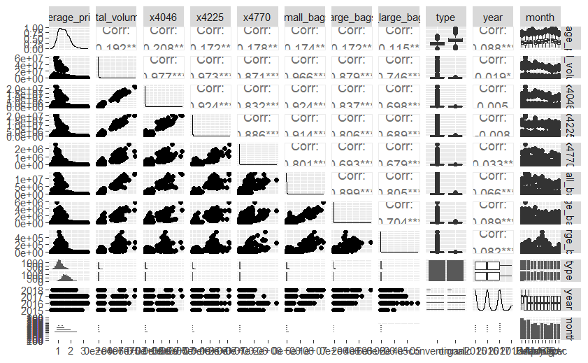

```r
ggpairs(avo_train)
```

## mod1a —-

From the plot it appears as though `type` may be an important factor;

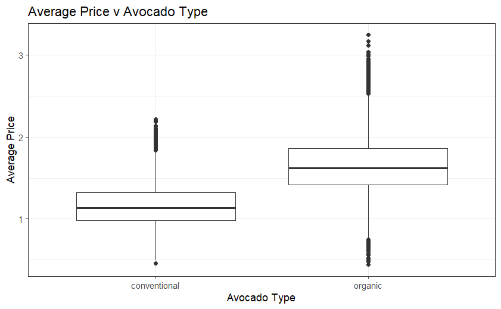

```r
avo_train %>%
  ggplot() +
  aes(x = type, y = average_price) +
  geom_boxplot() +
  theme_bw() +
  labs(title = "Average Price v Avocado Type",
       x = "Avocado Type",
       y = "Average Price")
```

`type` is a categorical variable, so should be checked for significance using ANOVA both with and without `type` included;

```r
anova(lm(average_price ~ . -type, data = avo_train))
```

```
Analysis of Variance Table

Response: average_price
                Df  Sum Sq Mean Sq  F value    Pr(>F)
total_volume     1   97.77  97.771 691.3293 < 2.2e-16 ***
x4046            1   23.62  23.622 167.0278 < 2.2e-16 ***
x4225            1    0.52   0.520   3.6773  0.055177 .
x4770            1    5.60   5.598  39.5855 3.220e-10 ***
small_bags       1    2.69   2.687  18.9999 1.315e-05 ***
large_bags       1    3.64   3.637  25.7145 4.002e-07 ***
x_large_bags     1    1.17   1.168   8.2579  0.004063 **
year             1   19.44  19.445 137.4918 < 2.2e-16 ***
month           11  177.72  16.156 114.2369 < 2.2e-16 ***
Residuals    16405 2320.08   0.141
---
Signif. codes:  0 ‘***’ 0.001 ‘**’ 0.01 ‘*’ 0.05 ‘.’ 0.1 ‘ ’ 1
```

```r
anova(lm(average_price ~ ., data = avo_train))
```

```
Analysis of Variance Table

Response: average_price
                Df  Sum Sq Mean Sq    F value    Pr(>F)
total_volume     1   97.77   97.77  1143.4384 < 2.2e-16 ***
x4046            1   23.62   23.62   276.2591 < 2.2e-16 ***
x4225            1    0.52    0.52     6.0821   0.01367 *
x4770            1    5.60    5.60    65.4732 6.300e-16 ***
small_bags       1    2.69    2.69    31.4253 2.106e-08 ***
large_bags       1    3.64    3.64    42.5311 7.160e-11 ***
x_large_bags     1    1.17    1.17    13.6583   0.00022 ***
type             1  912.06  912.06 10666.5625 < 2.2e-16 ***
year             1   21.70   21.70   253.8163 < 2.2e-16 ***
month           11  180.83   16.44   192.2551 < 2.2e-16 ***
Residuals    16404 1402.65    0.09
---
Signif. codes:  0 ‘***’ 0.001 ‘**’ 0.01 ‘*’ 0.05 ‘.’ 0.1 ‘ ’ 1
```

It looks like type *is* statistically significant. So the first model could be;

```r
mod1a <- lm(average_price ~ type, data = avo_train)
```

How does this look;

```r
summary(mod1a)
```

```
Call:
lm(formula = average_price ~ type, data = avo_train)

Residuals:
     Min       1Q   Median       3Q      Max
-1.21178 -0.20178 -0.02873  0.18822  1.59822

Coefficients:
            Estimate Std. Error t value Pr(>|t|)
(Intercept) 1.158731   0.003509  330.23   <2e-16 ***
typeorganic 0.493051   0.004953   99.56   <2e-16 ***
---
Signif. codes:  0 ‘***’ 0.001 ‘**’ 0.01 ‘*’ 0.05 ‘.’ 0.1 ‘ ’ 1

Residual standard error: 0.3174 on 16423 degrees of freedom
Multiple R-squared:  0.3764,    Adjusted R-squared:  0.3763
F-statistic:  9911 on 1 and 16423 DF,  p-value: < 2.2e-16
```

This suggests that 37% of the variance in our model could be explained by `type`.

Run the diagnostic plots;

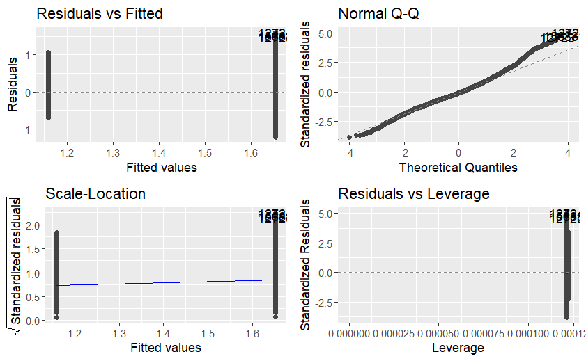

These look acceptable;

- The Residuals v Fitted are spread around 0 with a fairly flat line
- Q-Q plot is not perfect, but is on the line for the most part
- Scale - Location are in a band above the x-axis with only a very slight funnel effect evident.

## mod1b —-

At the very start it looked like `month` might also be a significant factor due to the seasonality of avocado growth and harvesting;

```r
mod1b <- lm(average_price ~ month, data = avo_train)
```

Check ANOVA with and without `month`;

```r
anova(lm(average_price ~ . -month, data = avo_train))
```

```
Analysis of Variance Table

Response: average_price
                Df  Sum Sq Mean Sq   F value    Pr(>F)
total_volume     1   97.77   97.77 1013.5395 < 2.2e-16 ***
x4046            1   23.62   23.62  244.8750 < 2.2e-16 ***
x4225            1    0.52    0.52    5.3911 0.0202514 *
x4770            1    5.60    5.60   58.0352 2.715e-14 ***
small_bags       1    2.69    2.69   27.8553 1.324e-07 ***
large_bags       1    3.64    3.64   37.6994 8.443e-10 ***
x_large_bags     1    1.17    1.17   12.1067 0.0005037 ***
type             1  912.06  912.06 9454.8007 < 2.2e-16 ***
year             1   21.70   21.70  224.9818 < 2.2e-16 ***
Residuals    16415 1583.47    0.10
---
Signif. codes:  0 ‘***’ 0.001 ‘**’ 0.01 ‘*’ 0.05 ‘.’ 0.1 ‘ ’ 1
```

```r
anova(mod1b)
```

```
Analysis of Variance Table

Response: average_price
             Df  Sum Sq Mean Sq F value    Pr(>F)
month        11  163.29 14.8447  97.891 < 2.2e-16 ***
Residuals 16413 2488.95  0.1516
---
Signif. codes:  0 ‘***’ 0.001 ‘**’ 0.01 ‘*’ 0.05 ‘.’ 0.1 ‘ ’ 1
```

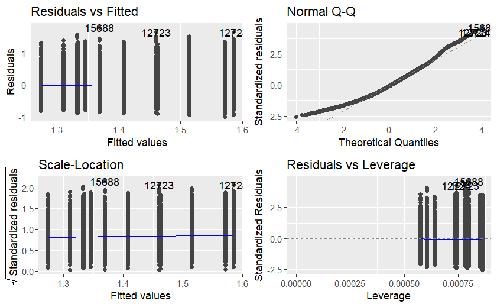

These don’t look perfect, but once again the residuals v fitted are spread across 0 with a fairy flat line, and the Q-Q plot is on the line for the mid- section of the points.

```r
summary(mod1b)
```

```
Call:
lm(formula = average_price ~ month, data = avo_train)

Residuals:
     Min       1Q   Median       3Q      Max
-0.99096 -0.29520 -0.03045  0.25428  1.80113

Coefficients:
             Estimate Std. Error t value Pr(>|t|)
(Intercept)  1.413834   0.003062 461.701  < 2e-16 ***
month.L      0.220906   0.010335  21.375  < 2e-16 ***
month.Q     -0.151823   0.010496 -14.465  < 2e-16 ***
month.C     -0.191169   0.010522 -18.169  < 2e-16 ***
month^4     -0.071126   0.010419  -6.827 8.99e-12 ***
month^5     -0.006538   0.010551  -0.620   0.5355
month^6      0.059227   0.010700   5.535 3.16e-08 ***
month^7     -0.003995   0.010467  -0.382   0.7027
month^8      0.030066   0.010528   2.856   0.0043 **
month^9      0.015865   0.010841   1.463   0.1434
month^10    -0.018941   0.010890  -1.739   0.0820 .
month^11     0.011065   0.010919   1.013   0.3109
---
Signif. codes:  0 ‘***’ 0.001 ‘**’ 0.01 ‘*’ 0.05 ‘.’ 0.1 ‘ ’ 1

Residual standard error: 0.3894 on 16413 degrees of freedom
Multiple R-squared:  0.06157,   Adjusted R-squared:  0.06094
F-statistic: 97.89 on 11 and 16413 DF,  p-value: < 2.2e-16
```

It looks like some of the months have a significant effect on average_price, although the overall R-squared is poor. If they are to be included then *all* months will be included.

Double check significance; run an ANOVA against the null model (intercept only);

```r
null_model <- lm(average_price ~ 1, data = avo_train)
month_model <- lm(average_price ~ month, data = avo_train)

anova(null_model, month_model)
```

```
Analysis of Variance Table

Model 1: average_price ~ 1
Model 2: average_price ~ month
  Res.Df    RSS Df Sum of Sq      F    Pr(>F)
1  16424 2652.2
2  16413 2488.9 11    163.29 97.891 < 2.2e-16 ***
---
Signif. codes:  0 ‘***’ 0.001 ‘**’ 0.01 ‘*’ 0.05 ‘.’ 0.1 ‘ ’ 1
```

So `month` is significant.

## mod1c —-

It would make sense that avocado size would impact on price:

```r
mod1c <- lm(average_price ~ x4046, data = avo_train)
```

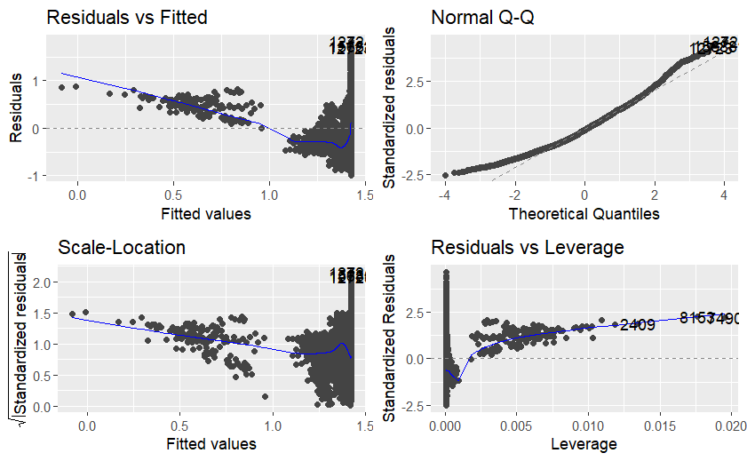

The diagnostic plots really don’t look acceptable. There are signs of non-normal distribution in every plot.

## mod1d —-

Try `x4225`;

```r
mod1d <- lm(average_price ~ x4225, data = avo_train)
```

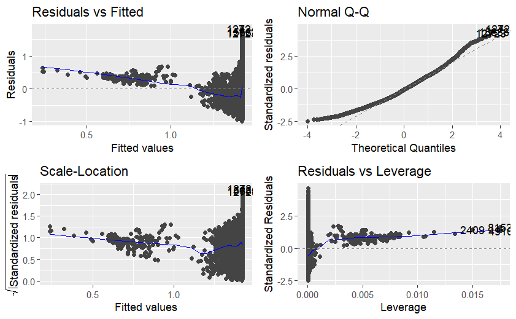

This is also unacceptable; try `x4770`

## mod1e —-

```r
mod1e <- lm(average_price ~ x4770, data = avo_train)
```

[figure not shown]

`x4770` is also unacceptable in isolation.

It looks like avocado size *might* be significant based on the ANOVA results earlier, but they don’t fit the linear model.

## Second Predictor

Looking at residuals;

```r
avo_residuals <- avo_train %>%
  add_residuals(mod1a) %>%
  select(-c(average_price, type))

avo_residuals_numeric <- avo_residuals %>%
  select_if(is.numeric)

avo_residuals_nonnumeric <- avo_residuals %>%
  select_if(function(x) !is.numeric(x))

avo_residuals_nonnumeric$resid <- avo_residuals$resid
```

[output not shown]

[output cut: 26 more lines]

[output not shown]

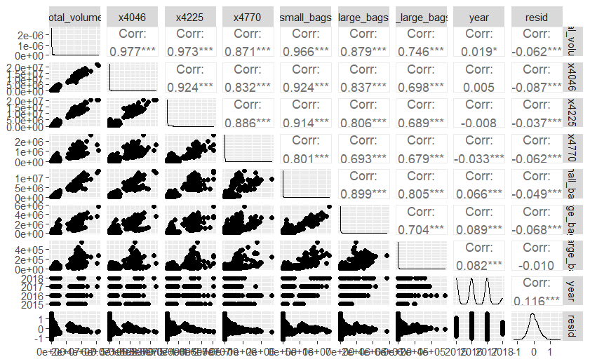

```r
ggpairs(avo_residuals_numeric)
```

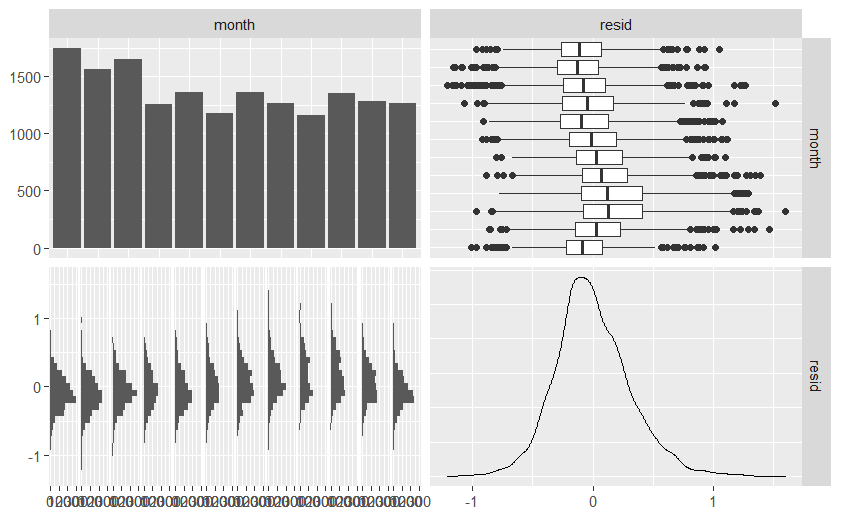

```r
ggpairs(avo_residuals_nonnumeric)
```

Month(as tried in mod1b) looks like it’s the next best against `resid`, although `year` also looks like it might be a factor.

## mod2a —-

Add month into the model, since the ANOVA etc above did show significance.

```r
summary(mod2a)
```

```
Call:
lm(formula = average_price ~ type + month, data = avo_train)

Residuals:
     Min       1Q   Median       3Q      Max
-1.14804 -0.19679 -0.01815  0.18690  1.55444

Coefficients:
             Estimate Std. Error t value Pr(>|t|)
(Intercept)  1.166541   0.003348 348.476  < 2e-16 ***
typeorganic  0.492607   0.004706 104.667  < 2e-16 ***
month.L      0.216114   0.008004  27.002  < 2e-16 ***
month.Q     -0.154173   0.008128 -18.968  < 2e-16 ***
month.C     -0.191551   0.008148 -23.508  < 2e-16 ***
month^4     -0.071300   0.008068  -8.837  < 2e-16 ***
month^5     -0.005331   0.008171  -0.652 0.514163
month^6      0.059084   0.008286   7.130 1.04e-12 ***
month^7     -0.002790   0.008106  -0.344 0.730673
month^8      0.029791   0.008154   3.654 0.000259 ***
month^9      0.012839   0.008396   1.529 0.126213
month^10    -0.021882   0.008433  -2.595 0.009476 **
month^11     0.015038   0.008456   1.778 0.075371 .
---
Signif. codes:  0 ‘***’ 0.001 ‘**’ 0.01 ‘*’ 0.05 ‘.’ 0.1 ‘ ’ 1

Residual standard error: 0.3016 on 16412 degrees of freedom
Multiple R-squared:  0.4372,    Adjusted R-squared:  0.4368
F-statistic:  1063 on 12 and 16412 DF,  p-value: < 2.2e-16
```

The adjusted R-squared indicates that 43% of the variance in our model could be explained by `type` + `month`.

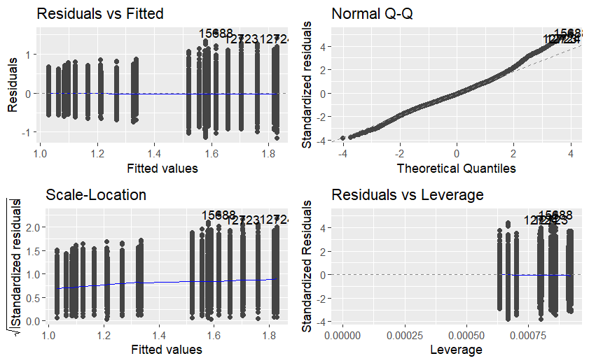

The diagnostic plots are generally acceptable for this model;

- Fitted v Residuals are spread across 0 with a fairly horizontal line.
- Q-Q plot shows around 75% of the points are on the line
- Scale - Location does not show any extreme funnelling effect

How does this compare with using `year` as the second predictor?

## mod2b —-

```r
summary(mod2b)
```

```
Call:
lm(formula = average_price ~ type + year, data = avo_train)

Residuals:
    Min      1Q  Median      3Q     Max
-1.2452 -0.2018 -0.0218  0.1873  1.6038

Coefficients:
              Estimate Std. Error t value Pr(>|t|)
(Intercept) -77.607741   5.272581  -14.72   <2e-16 ***
typeorganic   0.493458   0.004919  100.31   <2e-16 ***
year          0.039068   0.002615   14.94   <2e-16 ***
---
Signif. codes:  0 ‘***’ 0.001 ‘**’ 0.01 ‘*’ 0.05 ‘.’ 0.1 ‘ ’ 1

Residual standard error: 0.3152 on 16422 degrees of freedom
Multiple R-squared:  0.3847,    Adjusted R-squared:  0.3847
F-statistic:  5134 on 2 and 16422 DF,  p-value: < 2.2e-16
```

This shows that `year` has less of an effect than `month`. Make model 2 with `month`;

## Model 2 —-

And look at the residuals again;

```r
avo_residuals <- avo_train %>%
  add_residuals(mod1a) %>%
  select(-c(average_price, type, month))

avo_residuals_numeric <- avo_residuals %>%
  select_if(is.numeric)

avo_residuals_nonnumeric <- avo_residuals %>%
  select_if(function(x) !is.numeric(x))

avo_residuals_nonnumeric$resid <- avo_residuals$resid
```

[output not shown]

[output cut: 26 more lines]

[output not shown]

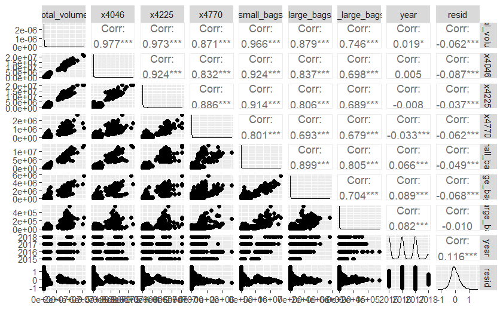

```r
ggpairs((avo_residuals_numeric))
```

$$average\_price \sim type + month$$

This suggests that the average price of avocados varies as a function of the type of avocado and the month of the year. This seems fairly sensible.